# Section 7.5: Reductions from 3SAT

# Last time: Polynomial-time Reductions

## Polynomial time reducibility

Let $A$ and $B$ be languages over an alphabet $\Sigma$. We say that $A$ is *polynomial time reducible* to $B$, written $A \leq_\text{P} B$, if there is a polynomial-time function (i.e., a *reduction*) $f:\Sigma^\ast \longrightarrow \Sigma^\ast$ such that, for every $w \in \Sigma^\ast$,
$$w \in A \Longleftrightarrow f(w) \in B$$

- If $A \leq_\text{P} B$ and $B \in \text{P}$, then $A \in \text{P}$.
- If $A$ is $\text{NP}$-complete and $B \in \text{NP}$, then $B$ is $\text{NP}$-complete.

## $\mathit{3SAT}$

A *3cnf-formula* is a Boolean formula of the form
$$(a_1 \vee b_1 \vee c_1) \wedge (a_2 \vee b_2 \vee c_2) \wedge \cdots
\wedge (a_k \vee b_k \vee c_k)$$

- The $a_i$’s, $b_i$’s, $c_i$’s are called *literals*. Each has the form $x_j$ or $\overline{x_j}$ for some *variable* $x_j$. The triples $(a_i \vee b_i \vee c_i)$ are called *clauses*.
- Such a formula is *satisfied* exactly when an assignment of 1’s and 0’s to the variables gives each clause at least one true literal.
- $\mathit{3SAT} = \{\langle \phi \rangle \mid \phi \text{ is a satisfiable 3cnf-formula} \}$.
- $\mathit{3SAT}$ is $\text{NP}$-complete.

# $\mathit{VERTEX\text{-}COVER}$ is $\text{NP}$-complete, again

## $\mathit{3SAT} \leq_\text{P} \mathit{VERTEX\text{-}COVER}$

- It is easy to check that $\mathit{VERTEX\text{-}COVER} \in \text{NP}$.
- We need a *polynomial time* reduction function that *inputs* a 3cnf-formula $\phi$, and outputs a graph $G$ and a number $k$.
- The graph needs to have a $k$-vertex cover exactly when the formula is satisfiable.

## Variable and clause “gadgets”

- For each *variable* $x_i$, make vertices labeled $x_i$ and $\overline{x_i}$ and connect them with an edge.
- For each *clause* $(a_i \wedge b_i \wedge c_i)$, make a triangle with vertices $a_i$, $b_i$, $c_i$.
- Add edges to connect each literal in the variable gadgets with the matching literals in all of the clause gadgets.

## Example

- Each variable is an edge $x_i -\!\!\!-\, \overline{x_i}$.
- Each clause is a triangle. Connect correponding literals.
- $(x_1 \vee x_1 \vee x_2) \wedge (\overline{x_1} \vee \overline{x_2} \vee \overline {x_2}) \wedge (\overline{x_1}\vee x_2 \vee x_2)$ maps to:

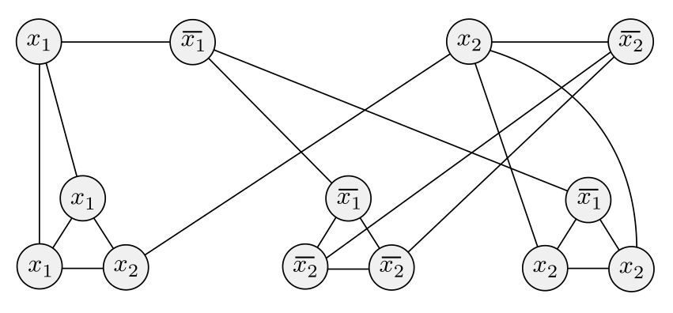

## Assignment $\Rightarrow$ Cover

Suppose you have $m$ variables and $l$ clauses. Given a satisfying assignment, make a vertex cover in the graph:

- Use the *true literals* from the variable gadgets. ($m$)
- Pick one true literal from each clause gadget, and use *the other two*. ($2l$)

Every edge in the variable gadgets and clause gadgets will be covered. So will the connecting edges, because one side is guaranteed to be 1. Set $k = m + 2l$.

## Example

- $(x_1 \vee x_1 \vee x_2) \wedge (\overline{x_1} \vee \overline{x_2} \vee \overline {x_2}) \wedge (\overline{x_1}\vee x_2 \vee x_2)$
- Satisfying assignment: $x_1 = 0$, $x_2 = 1$.

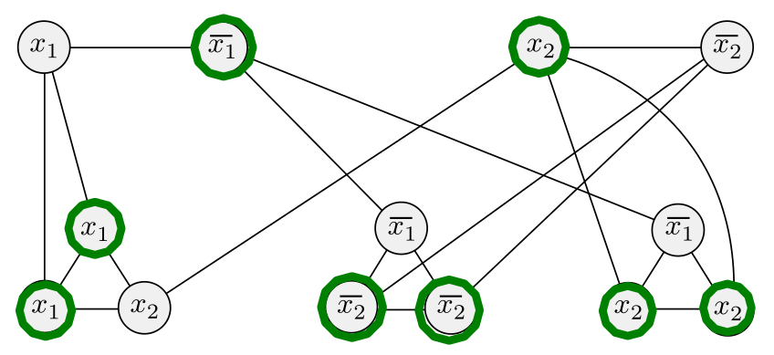

## Cover $\Rightarrow$ Assignment

Given a vertex cover with $k = m + 2l$ vertices,

- At least one vertex in each variable gadget must be included, because the connecting edge needs to be covered. ($m$)
- At least two vertices in each clause gadget must be included, because the connecting triangle must be covered. ($2l$)
- No other vertices can be included. Set *the included literals* from the variable gadgets to 1, and you get a satisfying assignment.

## Parts of the reduction argument

- *Describe a function* that inputs a $\langle \phi \rangle$ and outputs a $\langle G, k \rangle$.
- Show that $\langle \phi \rangle \in \mathit{3SAT}$ *iff* $\langle G, k \rangle \in \mathit{VERTEX\text{-}COVER}$
- Check that the function is computable in *polynomial time*.
- To show $\text{NP}$-completeness, you also need to check that $\mathit{VERTEX\text{-}COVER} \in \text{NP}$.

# $\mathit{3COLOR}$ is $\text{NP}$-complete

## $\mathit{3SAT} \leq_\text{P} \mathit{3COLOR}$

- We already showed that $\mathit{3COLOR} \in \text{NP}$.
- We need a *polynomial time* reduction function that *inputs* a 3cnf-formula $\phi$, and outputs a graph.
- The graph needs to be 3-colorable exactly when the formula is satisfiable.

## Palette, variable, and “OR” gadgets

Given a 3cnf-formula $\phi$,

- Each variable makes a $x_i -\!\!\!-\, \overline{x_i}$ edge.
- Each clause makes a combo of OR gadgets.
  - The OR gadget only gets colored F at the top if both its feet are colored F.

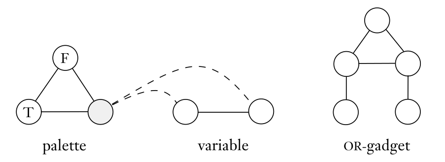

## Satisfiable $\Rightarrow$ 3-colorable

- Each clause has one true literal, so each OR-OR gadget has at least one non-red foot.
  - So the top of each OR-OR gadget doesn’t have to be red.

## 3-Colorable $\Rightarrow$ satisfiable

- Set the green nodes in the variable gadgets equal to 1.
  - Note: variable gadgets can’t be colored Navy.
- 3-colorability implies that none of the OR-OR gadgets has all red feet.
  - So all the the clauses have at least one true literal.

## Parts of the reduction argument

- *Describe a function* that inputs a $\langle \phi \rangle$ and outputs a $\langle G \rangle$.
- Show that $\langle \phi \rangle \in \mathit{3SAT}$ *iff* $\langle G \rangle \in \mathit{3COLOR}$.
- Check that the function is computable in *polynomial time*.
- To show $\text{NP}$-completeness, you also need to check that $\mathit{3COLOR} \in \text{NP}$.